# Distance part 2: transformations and clustering

Author

[Michael Love](http://mikelove.github.io)

Here we will examine distances a little more, including looking into data transformations to stabilize variance, and hierarchical clustering, which is a useful technique for unsupervised analysis of high-throughput data. We load the GEUVADIS RNA-seq dataset we prepared in distances.

```r
library(here)
library(DESeq2)
load(here("bioc","geuvadis.rda"))
```

# Picking a transformation

Last time I showed how we could scale the data to account for sequencing depth differences, and then take the log of the scaled counts. Here I want to emphasize that the logarithm, while convenient, is not necessarily an optimal transformation for computing distances between samples. We use the `normTransform` function to produce log scaled counts, and then we use the `meanSdPlot` function to plot the standard deviation of the log scaled counts for each gene over the mean:

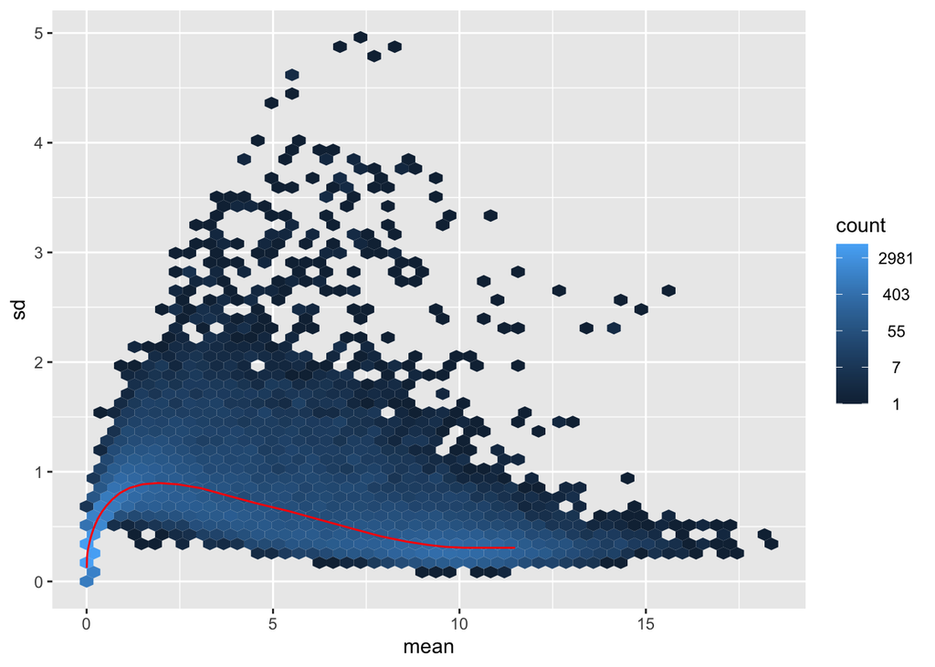

```r
ntd <- normTransform(dds)
library(vsn)
meanSdPlot(assay(ntd), ranks=FALSE)
```

This plot makes clear that, even after the log transform, the data exhibit systematic: [heteroskedasticity](https://en.wikipedia.org/wiki/Heteroscedasticity). We should not expect that all points fall on a horizontal line, but the red line shows that there is a *systematic trend* of variances on the mean. In particular, low counts, which are associated with less precision for calculating multiplicative changes between samples, have *higher* standard deviation, and so contribute *more* to a distance computation than high counts.

You can see this increased spread on the left side of an MA plot:

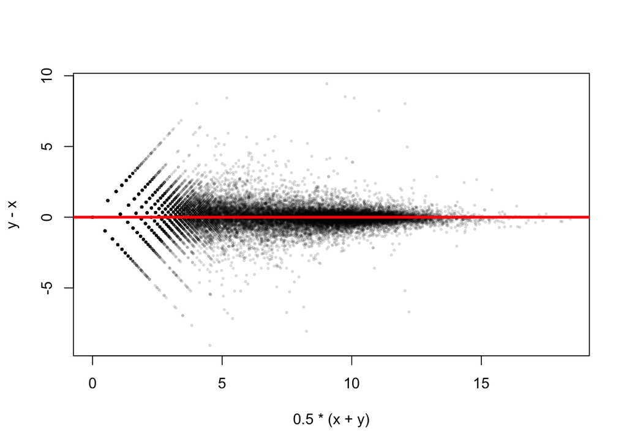

```r
x <- assay(ntd)[,1]
y <- assay(ntd)[,2]
plot(.5*(x + y), y - x,
     cex=.5, col=rgb(0,0,0,.1), pch=20)
abline(h=0, col="red", lwd=3)
```

A better transformation than log is to compute the [variance stabilizing transformation](https://en.wikipedia.org/wiki/Variance-stabilizing_transformation). An implementation of this for count data is the `vst` function in the DESeq2 package. This function also incorporates scaling for sequencing depth. We can examine how these two diagnostic plots change. The `meanSdPlot` has less of a systematic “hump” on the left side. Note: we do not seek a transformation which puts *all* the genes on a horizontal line – we expect high standard deviation for a subset of genes which show true biological differences across the samples. We only seek to remove *systematic trends* in the variance over the mean.

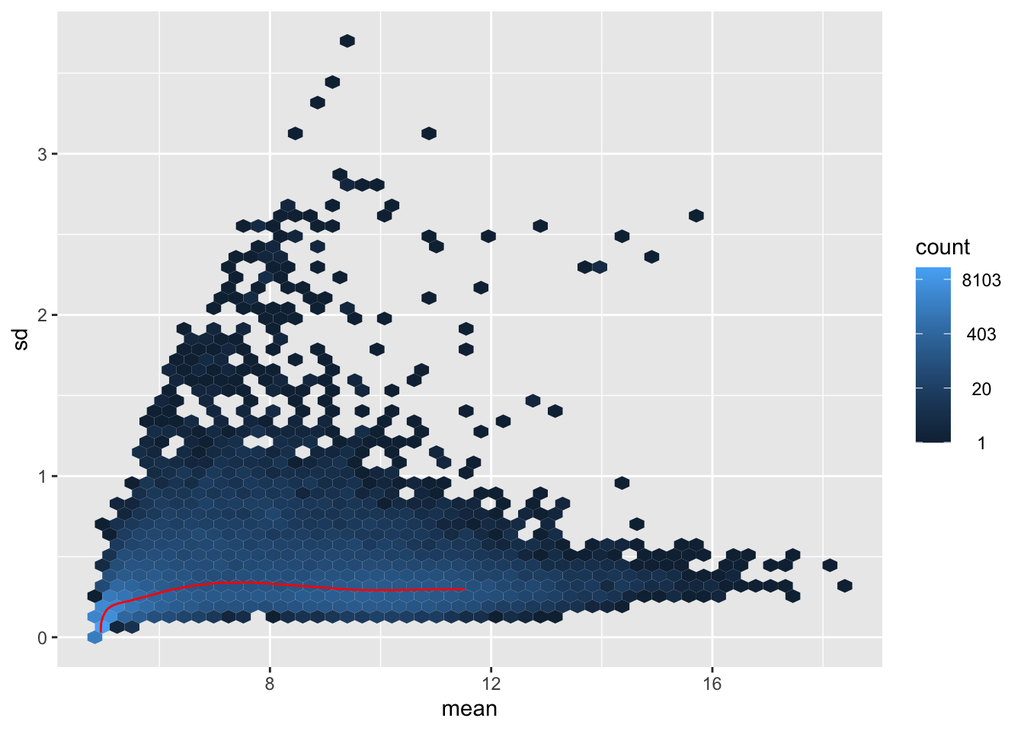

```r
vsd <- vst(dds)
meanSdPlot(assay(vsd), ranks=FALSE)
```

We can also see from an MA plot of two samples, that the increased spread of data on the left side has been reduced – now genes across the entire range have roughly equal “chance” at contributed to differences between samples.

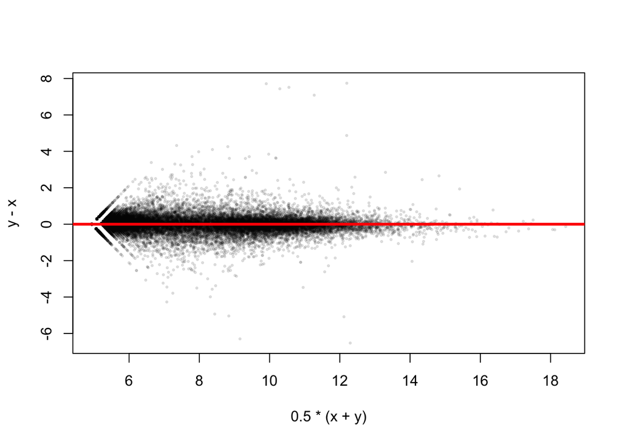

```r
x <- assay(vsd)[,1]
y <- assay(vsd)[,2]
plot(.5*(x + y), y - x,
     cex=.5, col=rgb(0,0,0,.1), pch=20)
abline(h=0, col="red", lwd=3)
```

To drive the point home, here I calculate the differences between two samples, and square them. These squared differences are the elements of a Euclidean distance computation. I also calculate the average signal strength on the log scale (the x-axis in the first MA plot above).

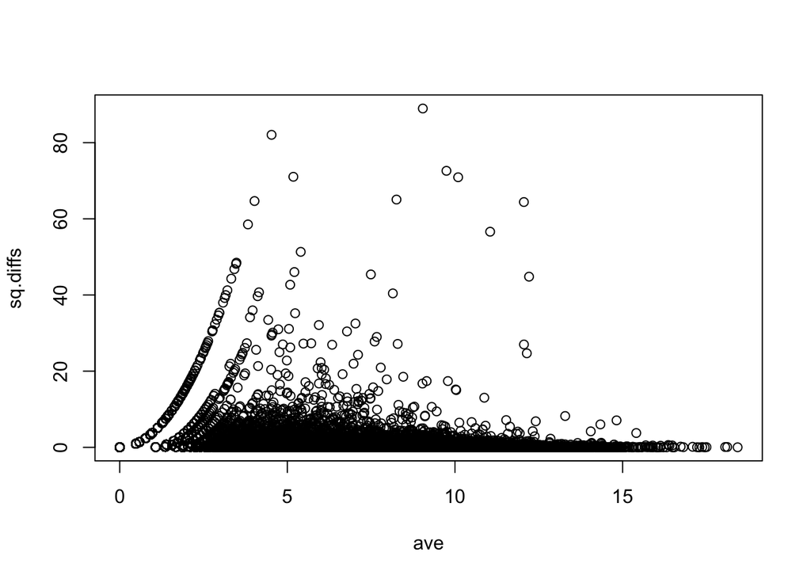

```r
sq.diffs <- (assay(ntd)[,2] - assay(ntd)[,1])^2
ave <- .5 * (assay(ntd)[,2] + assay(ntd)[,1])
plot(ave, sq.diffs)
```

Note that, if we just take the logarithm of scaled counts, genes with average signal less than 5 (32 on the count scale) contribute three times more to the sum than genes with average signal higher than 5. The inequality even holds for genes with average signal less than 3 (8 on the count scale).

```r
sum(sq.diffs[ave < 5])/sum(sq.diffs[ave > 5])
```

```
[1] 2.983881
```

```r
sum(sq.diffs[ave < 3])/sum(sq.diffs[ave > 3])
```

```
[1] 1.374198
```

# Drawing cluster dendrograms

For the rest of the document, I focus on drawing and working with hierachical clustering results. Let’s start with the basic code. We first subset to the top genes by variance, and then compute sample-sample distances of the variance stabilized data using the `dist` function:

```r
library(matrixStats)
rv <- rowVars(assay(vsd))
o <- order(rv,decreasing=TRUE)
dists <- dist(t(assay(vsd)[head(o,500),]))
```

The hierarchical clustering function in R is `hclust`, with a number of options you can read about in `?hclust`. The default `method` is `complete`. From the man page:

> Initially, each object is assigned to its own cluster and then the algorithm proceeds iteratively, at each stage joining the two most similar clusters, continuing until there is just a single cluster.

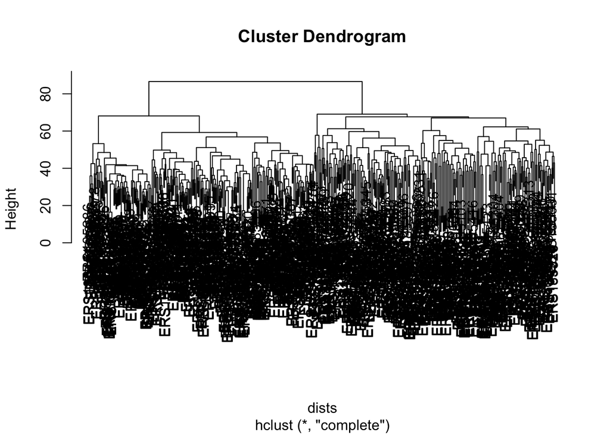

```r
hc <- hclust(dists)
plot(hc, labels=vsd$sample)
```

To get a better sense, let’s zoom into a single population, and see how the samples cluster within this group.

```r
library(magrittr)
table(vsd$population)
```

```
CEU FIN GBR TSI YRI
162 114 115 113 159
```

```r
idx <- vsd$population == "TSI"
vsd2 <- vsd[,idx]
vsd2$sample %<>% factor
```

As before, we compute distances and a hierarchical clustering, then we ask for the results to be converted to a *dendrogram* object:

```r
dists <- dist(t(assay(vsd2)[head(o,500),]))
hc <- hclust(dists)
dend <- as.dendrogram(hc)
```

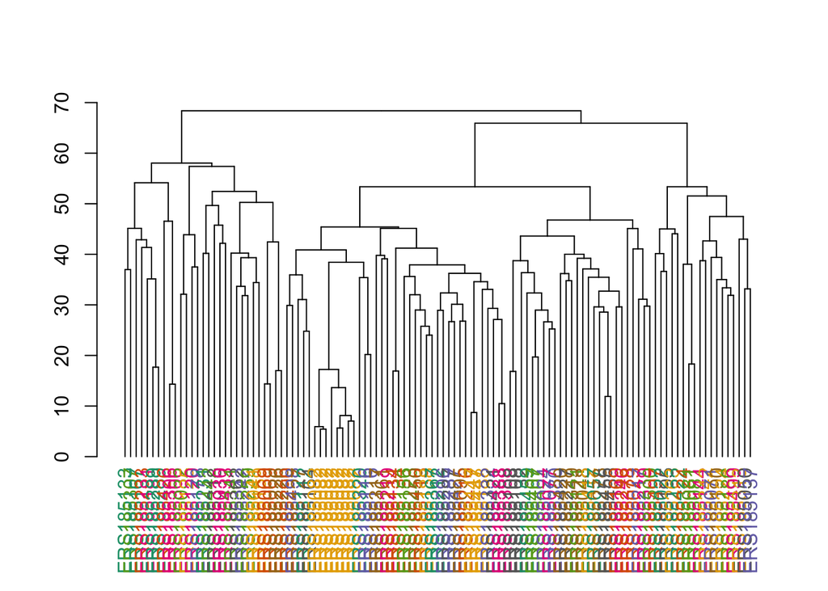

```r
suppressPackageStartupMessages(library(dendextend))
library(RColorBrewer)
palette(brewer.pal(8, "Dark2"))
o.dend <- order.dendrogram(dend)
labels(dend) <- vsd2$sample[o.dend]
labels_colors(dend) <- as.integer(vsd2$sample[o.dend])
plot(dend)
```

Note that, when we zoom into a single population, we can start to see the clustering of samples according to the sequencing center in which the samples were prepared. This indicates technical variation in the measurements.

```
using ntop=500 top features by variance
```

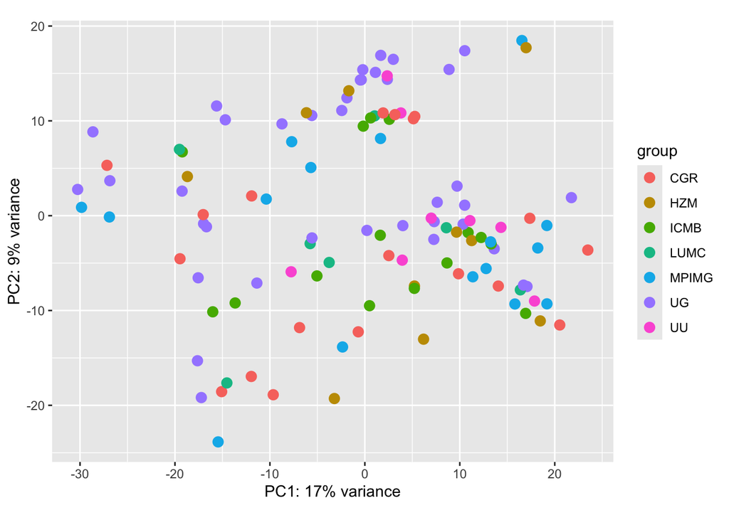

```r
plotPCA(vsd2, "center")
```

Finally, we show how to use hierarchical clustering to produce a distinct set of clusters, using the `cutree` function:

```r
vsd2$cluster <- cutree(hc, k=5)
head(vsd2$cluster)
```

```
ERR188398 ERR188110 ERR188253 ERR188384 ERR188254 ERR188357
        1         2         2         3         4         3
```

```r
table(vsd2$cluster)
```

```
 1  2  3  4  5
18 66 15  4 10
```

We can show these clusters on the dendrogram by re-coloring the labels:

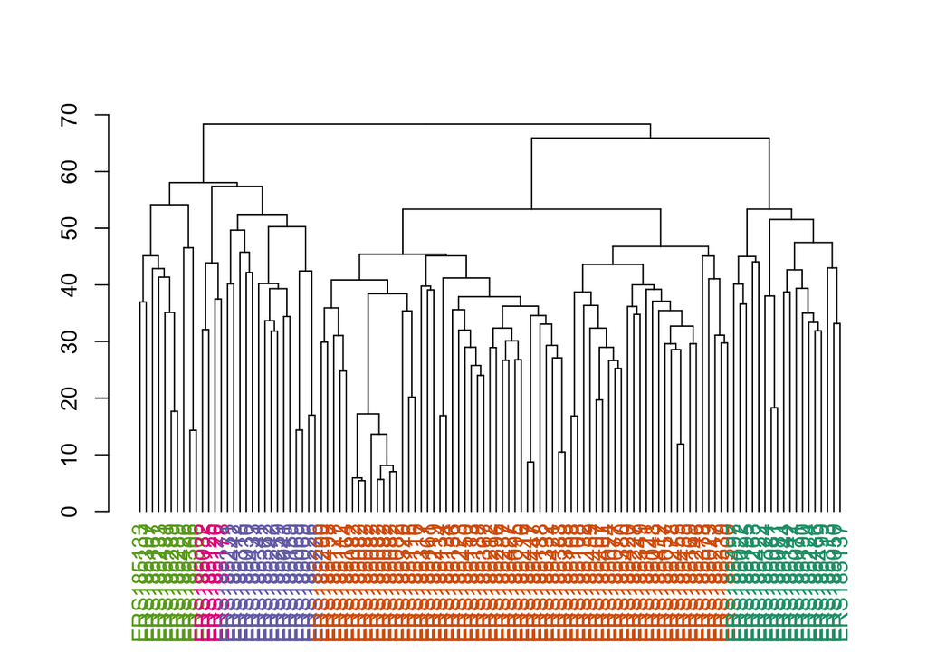

```r
labels_colors(dend) <- as.integer(vsd2$cluster[o.dend])
plot(dend)
```